# 17_cubic_from_zeros

## 17_cubic_from_zeros

#### Question

1. A cubic polynomial, $f(x)$, is generated by randomly selecting the three parameters, $B$, $C$, and $D$, in the equation below.

   $$f(x)~=~x^3+Bx^2+Cx+D$$

   You know the graph $y=f(x)$ has three distinct real roots at $x=-3$, $x=1$, and $x=3$, as shown below.

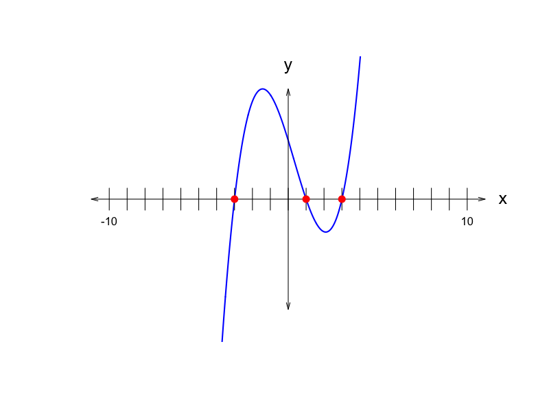

   Find $B$, $C$, and $D$.
   - $B=$
   - $C=$
   - $D=$

#### Question

2. A cubic polynomial, $f(x)$, is generated by randomly selecting the three parameters, $B$, $C$, and $D$, in the equation below.

   $$f(x)~=~x^3+Bx^2+Cx+D$$

   You know the graph $y=f(x)$ has three distinct real roots at $x=-6$, $x=-5$, and $x=1$, as shown below.

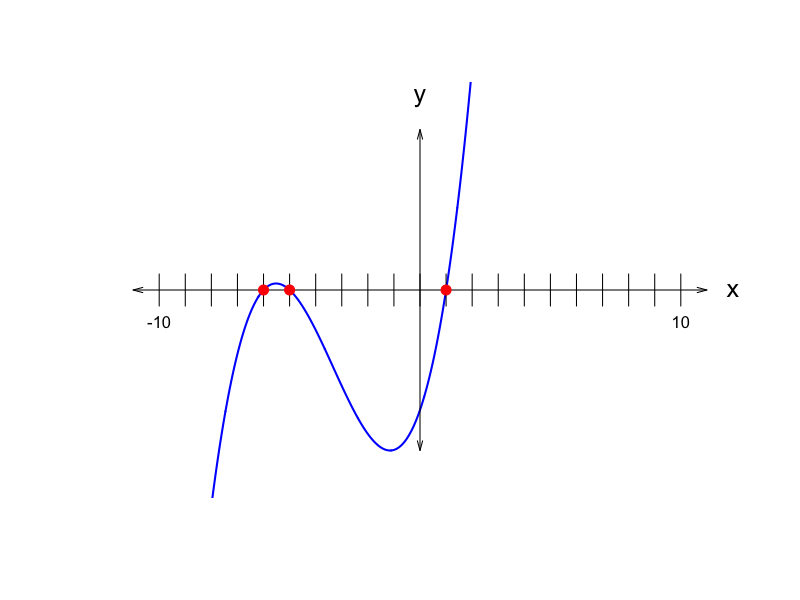

   Find $B$, $C$, and $D$.
   - $B=$
   - $C=$
   - $D=$

#### Question

3. A cubic polynomial, $f(x)$, is generated by randomly selecting the three parameters, $B$, $C$, and $D$, in the equation below.

   $$f(x)~=~x^3+Bx^2+Cx+D$$

   You know the graph $y=f(x)$ has three distinct real roots at $x=-5$, $x=-4$, and $x=5$, as shown below.

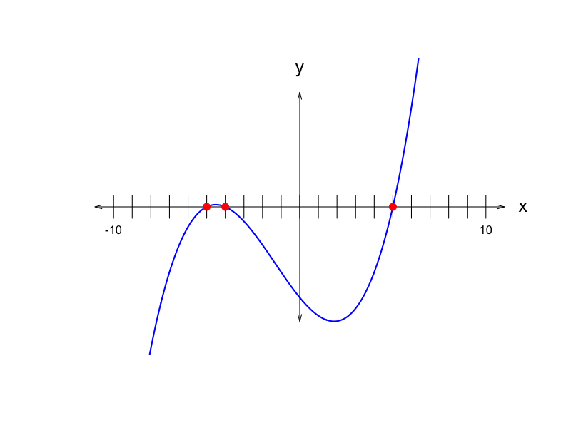

   Find $B$, $C$, and $D$.
   - $B=$
   - $C=$
   - $D=$

#### Question

4. A cubic polynomial, $f(x)$, is generated by randomly selecting the three parameters, $B$, $C$, and $D$, in the equation below.

   $$f(x)~=~x^3+Bx^2+Cx+D$$

   You know the graph $y=f(x)$ has three distinct real roots at $x=-6$, $x=-2$, and $x=5$, as shown below.

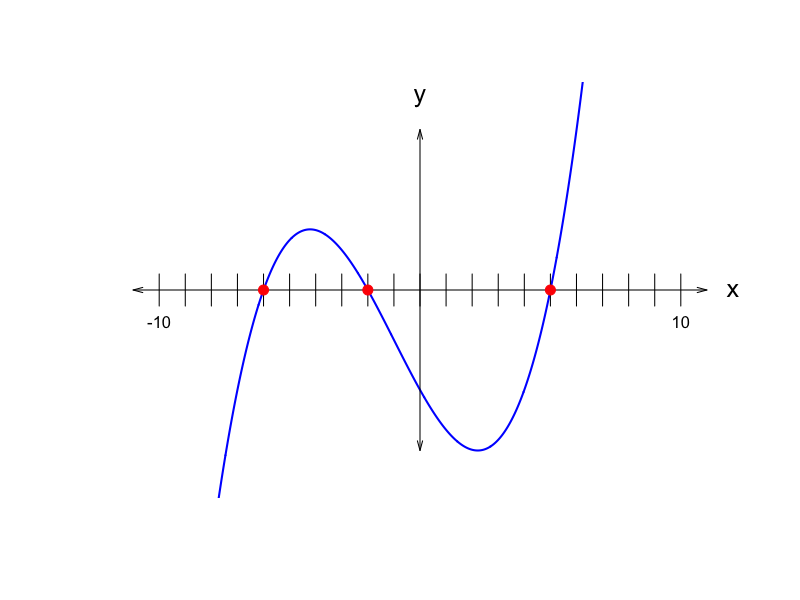

   Find $B$, $C$, and $D$.
   - $B=$
   - $C=$
   - $D=$

#### Question

5. A cubic polynomial, $f(x)$, is generated by randomly selecting the three parameters, $B$, $C$, and $D$, in the equation below.

   $$f(x)~=~x^3+Bx^2+Cx+D$$

   You know the graph $y=f(x)$ has three distinct real roots at $x=-1$, $x=4$, and $x=6$, as shown below.

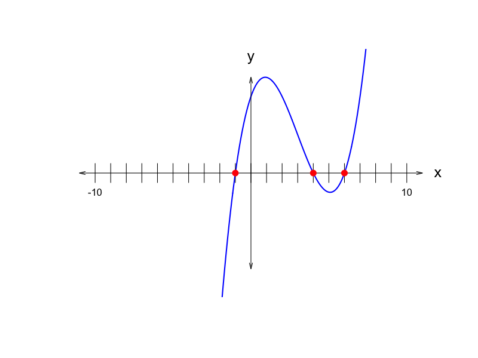

   Find $B$, $C$, and $D$.
   - $B=$
   - $C=$
   - $D=$

#### Question

6. A cubic polynomial, $f(x)$, is generated by randomly selecting the three parameters, $B$, $C$, and $D$, in the equation below.

   $$f(x)~=~x^3+Bx^2+Cx+D$$

   You know the graph $y=f(x)$ has three distinct real roots at $x=-2$, $x=1$, and $x=3$, as shown below.

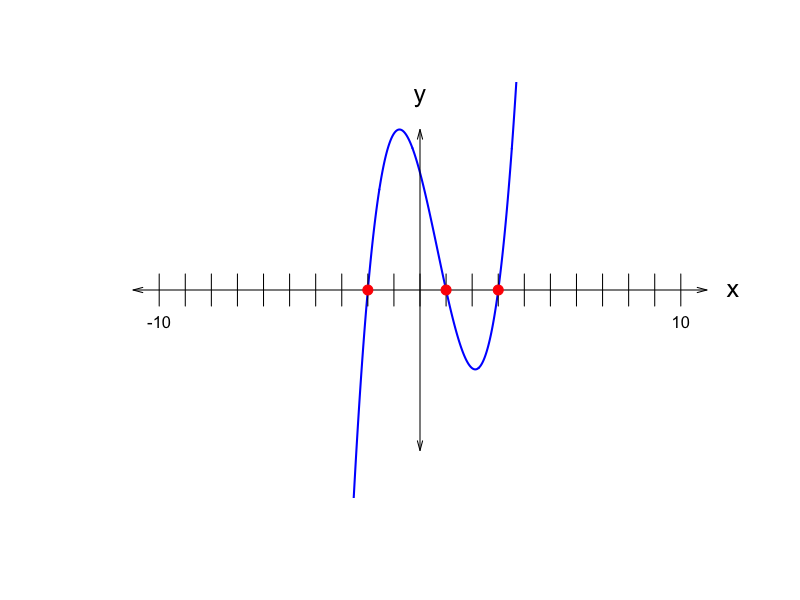

   Find $B$, $C$, and $D$.
   - $B=$
   - $C=$
   - $D=$

#### Question

7. A cubic polynomial, $f(x)$, is generated by randomly selecting the three parameters, $B$, $C$, and $D$, in the equation below.

   $$f(x)~=~x^3+Bx^2+Cx+D$$

   You know the graph $y=f(x)$ has three distinct real roots at $x=-2$, $x=3$, and $x=5$, as shown below.

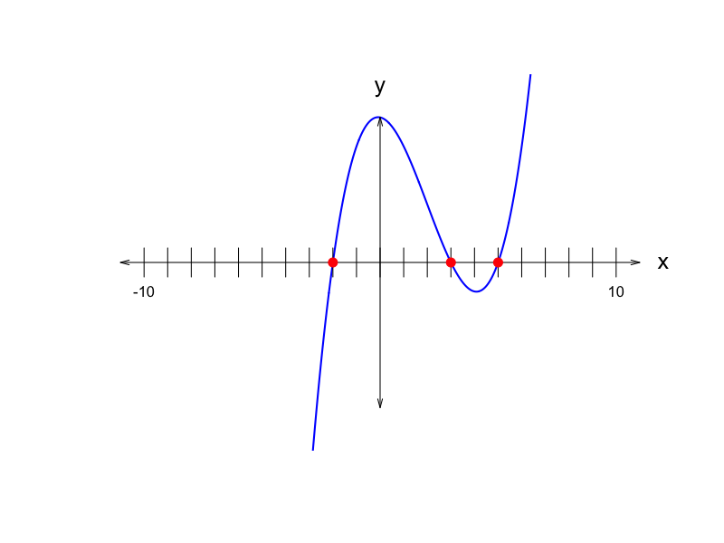

   Find $B$, $C$, and $D$.
   - $B=$
   - $C=$
   - $D=$

#### Question

8. A cubic polynomial, $f(x)$, is generated by randomly selecting the three parameters, $B$, $C$, and $D$, in the equation below.

   $$f(x)~=~x^3+Bx^2+Cx+D$$

   You know the graph $y=f(x)$ has three distinct real roots at $x=-5$, $x=-2$, and $x=6$, as shown below.

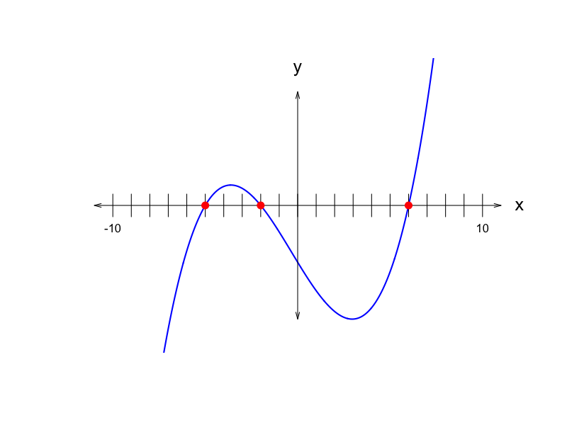

   Find $B$, $C$, and $D$.
   - $B=$
   - $C=$
   - $D=$